# 203BHW4

Biostat 203B

Author

Qingyuan Liu

Published

March 23, 2023

```r
# Load libraries
library(GGally)
library(gtsummary)
library(tidyverse)
library(tidymodels)
library(glmnet)
library(xgboost)
```

## 1 icu_cohort data

The goal is to predict the binary outcome `thirty_day_mort` (`TRUE` or `FALSE`) of patients.

Import the icu cohort dataset.

- Predictors to keep: demographic information (gender, age, marital status, ethnicity), first lab measurements during ICU stay, and first vital measurements during ICU stay.

```r
icu_cohort_hw4 <- readRDS("icu_cohort.rds") %>%
  select(-subject_id, -stay_id, -intime,
         -hadm_id, -first_careunit,
         -last_careunit, -outtime, -los,
         -anchor_age, -anchor_year,
         -anchor_year_group, -dod, -admittime,
         -dischtime, -deathtime, -admission_type,
         -admission_location, -admission_location,
         -discharge_location, -edregtime,
         -edouttime, -hospital_expire_flag,
         #Some demographic to delete
         -insurance, -language) %>%
  #change character variables to factor variables
  mutate(gender = as.factor(gender),
         marital_status = as.factor(marital_status),
         ethnicity = as.factor(ethnicity),
         #change outcome variable to factor
         thirty_day_mort = as.factor(thirty_day_mort)) %>%
  print(width = Inf)
```

```
# A tibble: 53,065 × 18
   gender marital_status ethnicity              age_real Sodium Glucose Chloride
   <fct>  <fct>          <fct>                     <int>  <dbl>   <dbl>    <dbl>
 1 M      MARRIED        OTHER                        80    129     106       97
 2 F      SINGLE         OTHER                        49    141      99      108
 3 F      WIDOWED        WHITE                        72    139      78      104
 4 F      SINGLE         WHITE                        69    129      94       95
 5 M      SINGLE         BLACK/AFRICAN AMERICAN       63    143      87      105
 6 F      DIVORCED       WHITE                        57    130      78       93
 7 F      MARRIED        HISPANIC/LATINO              46    137      99      104
 8 F      MARRIED        WHITE                        52    141     155      104
 9 F      SINGLE         WHITE                        24    138      85      103
10 F      MARRIED        WHITE                        49    135      81       98
   Potassium Creatinine Hematocrit Bicarbonate WhiteBloodCells
       <dbl>      <dbl>      <dbl>       <dbl>           <dbl>
```

[output cut: 35 more lines]

```r
# Numerical summaries stratified by the outcome `AHD`.
icu_cohort_hw4 %>% tbl_summary(by = thirty_day_mort)
```

| **Characteristic** | **FALSE**, N = 47,844<sup>1</sup> | **TRUE**, N = 5,221<sup>1</sup> |
| --- | --- | --- |
| gender |  |  |
| F | 20,900 (44%) | 2,414 (46%) |
| M | 26,944 (56%) | 2,807 (54%) |
| marital_status |  |  |
| DIVORCED | 3,399 (7.7%) | 296 (7.1%) |
| MARRIED | 22,057 (50%) | 2,055 (49%) |
| SINGLE | 13,168 (30%) | 1,003 (24%) |
| WIDOWED | 5,628 (13%) | 842 (20%) |
| Unknown | 3,592 | 1,025 |
| ethnicity |  |  |
| AMERICAN INDIAN/ALASKA NATIVE | 87 (0.2%) | 7 (0.1%) |
| ASIAN | 1,400 (2.9%) | 161 (3.1%) |
| BLACK/AFRICAN AMERICAN | 4,485 (9.4%) | 382 (7.3%) |
| HISPANIC/LATINO | 1,706 (3.6%) | 115 (2.2%) |
| OTHER | 2,319 (4.8%) | 211 (4.0%) |
| UNABLE TO OBTAIN | 636 (1.3%) | 119 (2.3%) |
| UNKNOWN | 4,673 (9.8%) | 1,138 (22%) |
| WHITE | 32,538 (68%) | 3,088 (59%) |
| age_real | 66 (53, 77) | 74 (61, 84) |
| Sodium | 137.0 (134.0, 139.0) | 136.0 (132.0, 140.0) |
| Unknown | 1,311 | 428 |
| Glucose | 103 (89, 122) | 103 (82, 131) |
| Unknown | 1,420 | 442 |
| Chloride | 102.0 (98.0, 105.0) | 100.0 (95.0, 105.0) |
| Unknown | 1,309 | 431 |
| Potassium | 3.70 (3.40, 4.10) | 3.60 (3.30, 4.20) |
| Unknown | 1,310 | 429 |
| Creatinine | 0.80 (0.60, 1.10) | 1.10 (0.70, 1.80) |
| Unknown | 1,321 | 438 |
| Hematocrit | 30 (25, 34) | 27 (23, 32) |
| Unknown | 1,379 | 448 |
| Bicarbonate | 22.0 (20.0, 24.0) | 18.0 (14.0, 22.0) |
| Unknown | 1,329 | 438 |
| WhiteBloodCells | 8.4 (6.3, 11.1) | 9.6 (6.4, 13.7) |
| Unknown | 1,517 | 457 |
| TemperatureFahrenheit | 97.50 (97.00, 97.90) | 97.20 (96.10, 97.70) |
| Unknown | 476 | 477 |
| NonInvasiveBloodPressuresystolic | 93 (83, 104) | 80 (66, 92) |
| Unknown | 421 | 262 |
| NonInvasiveBloodPressuremean | 59 (52, 68) | 51 (41, 60) |
| Unknown | 444 | 260 |
| RespiratoryRate | 11.0 (9.0, 13.0) | 9.0 (0.0, 13.0) |
| Unknown | 54 | 8 |
| HeartRate | 65 (57, 74) | 59 (27, 73) |
| Unknown | 13 | 2 |

<sup>1</sup> n (%); Median (IQR)

## 2 Initial split into test and non-test sets

Randomly split the data into 50% test data and 50% non-test data. Stratify on `thirty_day_mort`.

```r
# For reproducibility
set.seed(203)

data_split <- initial_split(
  icu_cohort_hw4,
  # stratify by 30-day-mortality
  strata = "thirty_day_mort",
  prop = 0.5
  )
data_split
```

```
<Training/Testing/Total>
<26532/26533/53065>
```

```r
ICU_other <- training(data_split)
dim(ICU_other)
```

```
[1] 26532    18
```

```r
ICU_test <- testing(data_split)
dim(ICU_test)
```

```
[1] 26533    18
```

## 3 Logit - Overview

1. Initial splitting to test and non-test sets.
2. Pre-processing of data: dummy coding categorical variables, standardizing numerical variables, imputing missing values, …
3. Tune the logistic regression with enet regularization using 5-fold cross-validation (CV) on the non-test data.
4. Choose the best model by CV and refit it on the whole non-test data.
5. Final classification on the test data.

## 4 Recipe (R)

check percentages of ethnicity in the ICU_cohort dataset

```r
icu_cohort_hw4 %>%
  select(ethnicity) %>%
  table() %>% prop.table()
```

```
ethnicity
AMERICAN INDIAN/ALASKA NATIVE                         ASIAN
                  0.001771412                   0.029416753
       BLACK/AFRICAN AMERICAN               HISPANIC/LATINO
                  0.091717705                   0.034316404
                        OTHER              UNABLE TO OBTAIN
                  0.047677377                   0.014227834
                      UNKNOWN                         WHITE
                  0.109507208                   0.671365307
```

```r
#Check number of missing values in marital status
icu_cohort_hw4 %>%
  select(marital_status) %>%
  filter(is.na(marital_status)) %>%
  nrow()
```

```
[1] 4617
```

- There are missing values in every numerical column except age_real. Missing proportion is not high (around 1500/50,000 at most), use median imputation, because many extreme outliers exist.
- In categorical variables marital_status and ethnicity, combine the levels with minimal frequency into “others”

```r
logit_recipe <-
  recipe(
    thirty_day_mort ~ .,
    data = ICU_other
  ) %>%
  # mean imputation for numerical variables
  step_impute_median(all_of(
    c("Sodium", "Glucose",
      "Chloride", "Potassium",
      "Creatinine", "Hematocrit",
      "Bicarbonate", "WhiteBloodCells",
      "TemperatureFahrenheit",
      "NonInvasiveBloodPressuresystolic",
      "NonInvasiveBloodPressuremean",
      "RespiratoryRate", "HeartRate")
    )) %>%
  # Impute the mode for missing values in marital status
  step_impute_mode("marital_status") %>%
  # combine levels in categorical variables into "other"
  step_mutate(
    ethnicity = as.factor(
      case_when(
      ethnicity %in% c("AMERICAN INDIAN/ALASKA NATIVE",
                       "OTHER",
                       "UNABLE TO OBTAIN",
                       "UNKNOWN")
      ~ "other",
      TRUE ~ ethnicity)
    )) %>%
  print(width = Inf) %>%
  # create traditional dummy variables
  step_dummy(all_nominal_predictors()) %>%
  # zero-variance filter
  step_zv(all_numeric_predictors()) %>%
  # center and scale numeric data
  step_normalize(all_numeric_predictors()) %>%
  # estimate the means and standard deviations
  prep(training = ICU_other, retain = TRUE)
logit_recipe
```

## 5 Model

```r
logit_mod <-
  logistic_reg(
    penalty = tune(),
    mixture = tune()
  ) %>%
  set_engine("glmnet", standardize = FALSE)
logit_mod
```

```
Logistic Regression Model Specification (classification)

Main Arguments:
  penalty = tune()
  mixture = tune()

Engine-Specific Arguments:
  standardize = FALSE

Computational engine: glmnet
```

## 6 Workflow in R

```r
logit_wf <- workflow() %>%
  add_recipe(logit_recipe) %>%
  add_model(logit_mod)
logit_wf
```

```
══ Workflow ════════════════════════════════════════════════════════════════════
Preprocessor: Recipe
Model: logistic_reg()

── Preprocessor ────────────────────────────────────────────────────────────────
6 Recipe Steps

• step_impute_median()
• step_impute_mode()
• step_mutate()
• step_dummy()
• step_zv()
• step_normalize()

── Model ───────────────────────────────────────────────────────────────────────
Logistic Regression Model Specification (classification)

Main Arguments:
  penalty = tune()
  mixture = tune()

Engine-Specific Arguments:
  standardize = FALSE

Computational engine: glmnet
```

## 7 Tuning grid

Here we tune the `penalty` and `mixture` hyperparameters.

```r
param_grid <- grid_regular(
  penalty(range = c(-6, 3)),
  mixture(),
  levels = c(100, 5)
  )
param_grid
```

```
# A tibble: 500 × 2
      penalty mixture
        <dbl>   <dbl>
 1 0.000001         0
 2 0.00000123       0
 3 0.00000152       0
 4 0.00000187       0
 5 0.00000231       0
 6 0.00000285       0
 7 0.00000351       0
 8 0.00000433       0
 9 0.00000534       0
10 0.00000658       0
# … with 490 more rows
```

## 8 Cross-validation (CV)

Set cross-validation partitions.

```r
set.seed(203)

folds <- vfold_cv(ICU_other, v = 5)
folds
```

```
#  5-fold cross-validation
# A tibble: 5 × 2
  splits               id
  <list>               <chr>
1 <split [21225/5307]> Fold1
2 <split [21225/5307]> Fold2
3 <split [21226/5306]> Fold3
4 <split [21226/5306]> Fold4
5 <split [21226/5306]> Fold5
```

Fit cross-validation.

```r
system.time({
logit_fit <- logit_wf %>%
  tune_grid(
    resamples = folds,
    grid = param_grid,
    metrics = metric_set(roc_auc, accuracy)
    )
})
```

```
   user  system elapsed
  83.17    9.22   92.52
```

```r
logit_fit
```

```
# Tuning results
# 5-fold cross-validation
# A tibble: 5 × 4
  splits               id    .metrics             .notes
  <list>               <chr> <list>               <list>
1 <split [21225/5307]> Fold1 <tibble [1,000 × 6]> <tibble [0 × 3]>
2 <split [21225/5307]> Fold2 <tibble [1,000 × 6]> <tibble [0 × 3]>
3 <split [21226/5306]> Fold3 <tibble [1,000 × 6]> <tibble [0 × 3]>
4 <split [21226/5306]> Fold4 <tibble [1,000 × 6]> <tibble [0 × 3]>
5 <split [21226/5306]> Fold5 <tibble [1,000 × 6]> <tibble [0 × 3]>
```

Visualize CV results:

```
# A tibble: 1,000 × 8
      penalty mixture .metric  .estimator  mean     n std_err
        <dbl>   <dbl> <chr>    <chr>      <dbl> <int>   <dbl>
 1 0.000001         0 accuracy binary     0.920     5 0.00125
 2 0.000001         0 roc_auc  binary     0.810     5 0.00696
 3 0.00000123       0 accuracy binary     0.920     5 0.00125
 4 0.00000123       0 roc_auc  binary     0.810     5 0.00696
 5 0.00000152       0 accuracy binary     0.920     5 0.00125
 6 0.00000152       0 roc_auc  binary     0.810     5 0.00696
 7 0.00000187       0 accuracy binary     0.920     5 0.00125
 8 0.00000187       0 roc_auc  binary     0.810     5 0.00696
 9 0.00000231       0 accuracy binary     0.920     5 0.00125
10 0.00000231       0 roc_auc  binary     0.810     5 0.00696
   .config
   <chr>
 1 Preprocessor1_Model001
 2 Preprocessor1_Model001
 3 Preprocessor1_Model002
 4 Preprocessor1_Model002
 5 Preprocessor1_Model003
 6 Preprocessor1_Model003
 7 Preprocessor1_Model004
 8 Preprocessor1_Model004
 9 Preprocessor1_Model005
10 Preprocessor1_Model005
# … with 990 more rows
```

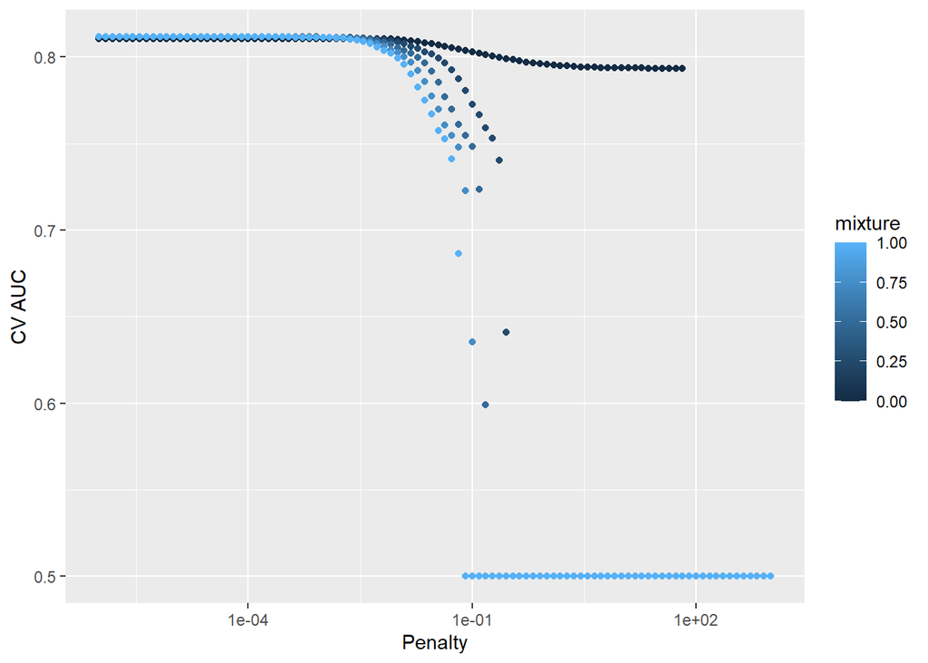

```r
logit_fit %>%
  collect_metrics() %>%
  print(width = Inf) %>%
  filter(.metric == "roc_auc") %>%
  ggplot(mapping = aes(x = penalty, y = mean, color = mixture)) +
  geom_point() +
  labs(x = "Penalty", y = "CV AUC") +
  scale_x_log10()
```

Show the top 5 models.

```r
logit_fit %>%
  show_best("roc_auc")
```

```
# A tibble: 5 × 8
     penalty mixture .metric .estimator  mean     n std_err .config
       <dbl>   <dbl> <chr>   <chr>      <dbl> <int>   <dbl> <chr>
1 0.000001       0.5 roc_auc binary     0.812     5 0.00688 Preprocessor1_Model…
2 0.00000123     0.5 roc_auc binary     0.812     5 0.00688 Preprocessor1_Model…
3 0.00000152     0.5 roc_auc binary     0.812     5 0.00688 Preprocessor1_Model…
4 0.00000187     0.5 roc_auc binary     0.812     5 0.00688 Preprocessor1_Model…
5 0.00000231     0.5 roc_auc binary     0.812     5 0.00688 Preprocessor1_Model…
```

Let’s select the best model.

```r
best_logit <- logit_fit %>%
  select_best("roc_auc")
best_logit
```

```
# A tibble: 1 × 3
   penalty mixture .config
     <dbl>   <dbl> <chr>
1 0.000001     0.5 Preprocessor1_Model201
```

## 9 Finalize our model

Now we are done tuning. Finally, let’s fit this final model to the whole training data and use our test data to estimate the model performance we expect to see with new data.

```r
# Final workflow
final_wf <- logit_wf %>%
  finalize_workflow(best_logit)
final_wf
```

```
══ Workflow ════════════════════════════════════════════════════════════════════
Preprocessor: Recipe
Model: logistic_reg()

── Preprocessor ────────────────────────────────────────────────────────────────
6 Recipe Steps

• step_impute_median()
• step_impute_mode()
• step_mutate()
• step_dummy()
• step_zv()
• step_normalize()

── Model ───────────────────────────────────────────────────────────────────────
Logistic Regression Model Specification (classification)

Main Arguments:
  penalty = 1e-06
  mixture = 0.5

Engine-Specific Arguments:
  standardize = FALSE

Computational engine: glmnet
```

```r
# Fit the whole training set, then predict the test cases
final_fit <-
  final_wf %>%
  last_fit(data_split)
final_fit
```

```
# Resampling results
# Manual resampling
# A tibble: 1 × 6
  splits                id               .metrics .notes   .predict…¹ .workflow
  <list>                <chr>            <list>   <list>   <list>     <list>
1 <split [26532/26533]> train/test split <tibble> <tibble> <tibble>   <workflow>
# … with abbreviated variable name ¹.predictions
```

```r
# Test metrics
final_fit %>%
  collect_metrics()
```

```
# A tibble: 2 × 4
  .metric  .estimator .estimate .config
  <chr>    <chr>          <dbl> <chr>
1 accuracy binary         0.919 Preprocessor1_Model1
2 roc_auc  binary         0.803 Preprocessor1_Model1
```

## 10 RF - Overview

1. Initial splitting to test and non-test sets, (use same splitting from the logistic model).
2. Pre-processing of data: dummy coding categorical variables, standardizing numerical variables, imputing missing values, …
3. Tune the random forest using 5-fold cross-validation (CV) on the non-test data.
4. Choose the best model by CV and refit it on the whole non-test data.
5. Final classification on the test data.

## 11 Recipe (R)

- Same as the recipe in logistic model, but the dummy variable step is not necessary

```r
rf_recipe <-
  recipe(
    thirty_day_mort ~ .,
    data = ICU_other
  ) %>%
  # mean imputation for numerical variables
  step_impute_median(all_of(
    c("Sodium", "Glucose",
      "Chloride", "Potassium",
      "Creatinine", "Hematocrit",
      "Bicarbonate", "WhiteBloodCells",
      "TemperatureFahrenheit",
      "NonInvasiveBloodPressuresystolic",
      "NonInvasiveBloodPressuremean",
      "RespiratoryRate", "HeartRate")
    )) %>%
  # Mode imputation for marital status
  step_impute_mode("marital_status") %>%
  # combine levels in categorical variables into "other"
  step_mutate(
    ethnicity = as.factor(
      case_when(
      ethnicity %in% c("AMERICAN INDIAN/ALASKA NATIVE",
                       "OTHER",
                       "UNABLE TO OBTAIN",
                       "UNKNOWN")
      ~ "other",
      TRUE ~ ethnicity)
    )) %>%
  print(width = Inf) %>%
  # zero-variance filter
  step_zv(all_numeric_predictors()) %>%
  # center and scale numeric data
  step_normalize(all_numeric_predictors()) %>%
  # estimate the means and standard deviations
  prep(training = ICU_other, retain = TRUE)
  # dummy variable step is not needed for random forest
rf_recipe
```

## 12 Model

```r
rf_mod <-
  rand_forest(
    mode = "classification",
    # Number of predictors randomly sampled in each split
    mtry = tune(),
    # Number of trees in ensemble
    trees = tune()
  ) %>%
  set_engine("ranger")
rf_mod
```

```
Random Forest Model Specification (classification)

Main Arguments:
  mtry = tune()
  trees = tune()

Computational engine: ranger
```

## 13 Workflow in R

```r
rf_wf <- workflow() %>%
  add_recipe(rf_recipe) %>%
  add_model(rf_mod)
rf_wf
```

```
══ Workflow ════════════════════════════════════════════════════════════════════
Preprocessor: Recipe
Model: rand_forest()

── Preprocessor ────────────────────────────────────────────────────────────────
5 Recipe Steps

• step_impute_median()
• step_impute_mode()
• step_mutate()
• step_zv()
• step_normalize()

── Model ───────────────────────────────────────────────────────────────────────
Random Forest Model Specification (classification)

Main Arguments:
  mtry = tune()
  trees = tune()

Computational engine: ranger
```

## 14 Tuning grid

Here we tune the number of trees `trees` and the number of features to use in each split `mtry`.

```r
param_grid <- grid_regular(
  trees(range = c(100L, 300L)),
  mtry(range = c(1L, 5L)),
  levels = c(3, 5)
  )
param_grid
```

```
# A tibble: 15 × 2
   trees  mtry
   <int> <int>
 1   100     1
 2   200     1
 3   300     1
 4   100     2
 5   200     2
 6   300     2
 7   100     3
 8   200     3
 9   300     3
10   100     4
11   200     4
12   300     4
13   100     5
14   200     5
15   300     5
```

## 15 Cross-validation (CV)

Set cross-validation partitions. Use a different seed for the fold of random forest, so the see is set to 204.

```r
set.seed(204)

rf_folds <- vfold_cv(ICU_other, v = 5)
rf_folds
```

```
#  5-fold cross-validation
# A tibble: 5 × 2
  splits               id
  <list>               <chr>
1 <split [21225/5307]> Fold1
2 <split [21225/5307]> Fold2
3 <split [21226/5306]> Fold3
4 <split [21226/5306]> Fold4
5 <split [21226/5306]> Fold5
```

Fit cross-validation.

```r
rf_fit <- rf_wf %>%
  tune_grid(
    resamples = rf_folds,
    grid = param_grid,
    metrics = metric_set(roc_auc, accuracy)
    )
rf_fit
```

```
# Tuning results
# 5-fold cross-validation
# A tibble: 5 × 4
  splits               id    .metrics          .notes
  <list>               <chr> <list>            <list>
1 <split [21225/5307]> Fold1 <tibble [30 × 6]> <tibble [0 × 3]>
2 <split [21225/5307]> Fold2 <tibble [30 × 6]> <tibble [0 × 3]>
3 <split [21226/5306]> Fold3 <tibble [30 × 6]> <tibble [0 × 3]>
4 <split [21226/5306]> Fold4 <tibble [30 × 6]> <tibble [0 × 3]>
5 <split [21226/5306]> Fold5 <tibble [30 × 6]> <tibble [0 × 3]>
```

Visualize CV results:

```
# A tibble: 30 × 8
    mtry trees .metric  .estimator  mean     n std_err .config
   <int> <int> <chr>    <chr>      <dbl> <int>   <dbl> <chr>
 1     1   100 accuracy binary     0.924     5 0.00291 Preprocessor1_Model01
 2     1   100 roc_auc  binary     0.875     5 0.00164 Preprocessor1_Model01
 3     1   200 accuracy binary     0.924     5 0.00257 Preprocessor1_Model02
 4     1   200 roc_auc  binary     0.878     5 0.00304 Preprocessor1_Model02
 5     1   300 accuracy binary     0.924     5 0.00263 Preprocessor1_Model03
 6     1   300 roc_auc  binary     0.879     5 0.00242 Preprocessor1_Model03
 7     2   100 accuracy binary     0.931     5 0.00184 Preprocessor1_Model04
 8     2   100 roc_auc  binary     0.878     5 0.00214 Preprocessor1_Model04
 9     2   200 accuracy binary     0.931     5 0.00200 Preprocessor1_Model05
10     2   200 roc_auc  binary     0.882     5 0.00153 Preprocessor1_Model05
# … with 20 more rows
```

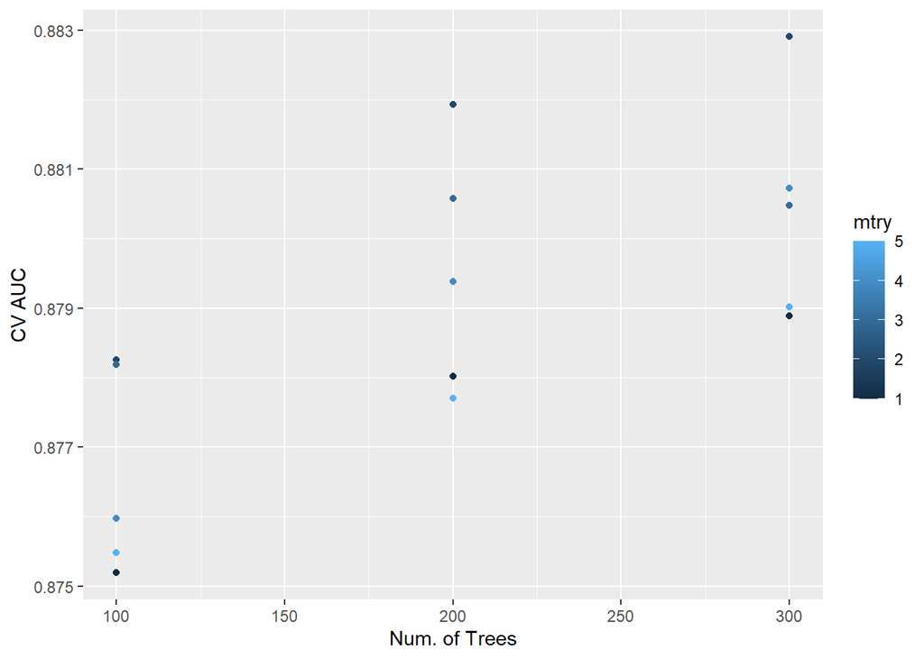

```r
rf_fit %>%
  collect_metrics() %>%
  print(width = Inf) %>%
  filter(.metric == "roc_auc") %>%
  ggplot(mapping = aes(x = trees, y = mean, color = mtry)) +
  geom_point() +
  # geom_line() +
  labs(x = "Num. of Trees", y = "CV AUC")
```

Show the top 5 models.

```r
rf_fit %>%
  show_best("roc_auc")
```

```
# A tibble: 5 × 8
   mtry trees .metric .estimator  mean     n std_err .config
  <int> <int> <chr>   <chr>      <dbl> <int>   <dbl> <chr>
1     2   300 roc_auc binary     0.883     5 0.00199 Preprocessor1_Model06
2     2   200 roc_auc binary     0.882     5 0.00153 Preprocessor1_Model05
3     4   300 roc_auc binary     0.881     5 0.00146 Preprocessor1_Model12
4     3   200 roc_auc binary     0.881     5 0.00174 Preprocessor1_Model08
5     3   300 roc_auc binary     0.880     5 0.00149 Preprocessor1_Model09
```

Let’s select the best model.

```r
best_rf <- rf_fit %>%
  select_best("roc_auc")
best_rf
```

```
# A tibble: 1 × 3
   mtry trees .config
  <int> <int> <chr>
1     2   300 Preprocessor1_Model06
```

## 16 Finalize our model

Now we are done tuning. Finally, let’s fit this final model to the whole training data and use our test data to estimate the model performance we expect to see with new data.

```r
# Final workflow
rf_final_wf <- rf_wf %>%
  finalize_workflow(best_rf)
rf_final_wf
```

```
══ Workflow ════════════════════════════════════════════════════════════════════
Preprocessor: Recipe
Model: rand_forest()

── Preprocessor ────────────────────────────────────────────────────────────────
5 Recipe Steps

• step_impute_median()
• step_impute_mode()
• step_mutate()
• step_zv()
• step_normalize()

── Model ───────────────────────────────────────────────────────────────────────
Random Forest Model Specification (classification)

Main Arguments:
  mtry = 2
  trees = 300

Computational engine: ranger
```

```r
# Fit the whole training set, then predict the test cases
rf_final_fit <-
  rf_final_wf %>%
  last_fit(data_split)
rf_final_fit
```

```
# Resampling results
# Manual resampling
# A tibble: 1 × 6
  splits                id               .metrics .notes   .predict…¹ .workflow
  <list>                <chr>            <list>   <list>   <list>     <list>
1 <split [26532/26533]> train/test split <tibble> <tibble> <tibble>   <workflow>
# … with abbreviated variable name ¹.predictions
```

```r
# Test metrics
rf_final_fit %>%
  collect_metrics()
```

```
# A tibble: 2 × 4
  .metric  .estimator .estimate .config
  <chr>    <chr>          <dbl> <chr>
1 accuracy binary         0.932 Preprocessor1_Model1
2 roc_auc  binary         0.889 Preprocessor1_Model1
```

## 17 XGB_Overview

1. Initial splitting to test and non-test sets –use same split from logistic
2. Pre-processing of data: dummy coding categorical variables, standardizing numerical variables, imputing missing values, …
3. Tune the gradient boosting algorithm using 5-fold cross-validation (CV) on the non-test data.
4. Choose the best model by CV and refit it on the whole non-test data.
5. Final classification on the test data.

## 18 Recipe (R)

the recipe of gb requires creating dummy variables:

```r
gb_recipe <-
  recipe(
    thirty_day_mort ~ .,
    data = ICU_other
  ) %>%
  # mean imputation for numerical variables
  step_impute_median(all_of(
    c("Sodium", "Glucose",
      "Chloride", "Potassium",
      "Creatinine", "Hematocrit",
      "Bicarbonate", "WhiteBloodCells",
      "TemperatureFahrenheit",
      "NonInvasiveBloodPressuresystolic",
      "NonInvasiveBloodPressuremean",
      "RespiratoryRate", "HeartRate")
    )) %>%
  # mode imputation for marital status
  step_impute_mode("marital_status") %>%
  # combine levels in categorical variables into "other"
  step_mutate(
    ethnicity = as.factor(
      case_when(
      ethnicity %in% c("AMERICAN INDIAN/ALASKA NATIVE",
                       "OTHER",
                       "UNABLE TO OBTAIN",
                       "UNKNOWN")
      ~ "other",
      TRUE ~ ethnicity)
    )) %>%
  print(width = Inf) %>%
  # create traditional dummy variables (necessary for xgboost)
  step_dummy(all_nominal_predictors()) %>%
  # zero-variance filter
  step_zv(all_numeric_predictors()) %>%
  # center and scale numeric data
  step_normalize(all_numeric_predictors()) %>%
  # estimate the means and standard deviations
  prep(training = ICU_other, retain = TRUE)
gb_recipe
```

## 19 Model

```r
gb_mod <-
  boost_tree(
    mode = "classification",
    trees = 1000,
    tree_depth = tune(),
    learn_rate = tune()
  ) %>%
  set_engine("xgboost")
gb_mod
```

```
Boosted Tree Model Specification (classification)

Main Arguments:
  trees = 1000
  tree_depth = tune()
  learn_rate = tune()

Computational engine: xgboost
```

## 20 Workflow in R

```r
gb_wf <- workflow() %>%
  add_recipe(gb_recipe) %>%
  add_model(gb_mod)
gb_wf
```

```
══ Workflow ════════════════════════════════════════════════════════════════════
Preprocessor: Recipe
Model: boost_tree()

── Preprocessor ────────────────────────────────────────────────────────────────
6 Recipe Steps

• step_impute_median()
• step_impute_mode()
• step_mutate()
• step_dummy()
• step_zv()
• step_normalize()

── Model ───────────────────────────────────────────────────────────────────────
Boosted Tree Model Specification (classification)

Main Arguments:
  trees = 1000
  tree_depth = tune()
  learn_rate = tune()

Computational engine: xgboost
```

## 21 Tuning grid

```r
param_grid <- grid_regular(
  tree_depth(range = c(1L, 3L)),
  learn_rate(range = c(-5, 2), trans = log10_trans()),
  levels = c(3, 10)
  )
param_grid
```

```
# A tibble: 30 × 2
   tree_depth learn_rate
        <int>      <dbl>
 1          1  0.00001
 2          2  0.00001
 3          3  0.00001
 4          1  0.0000599
 5          2  0.0000599
 6          3  0.0000599
 7          1  0.000359
 8          2  0.000359
 9          3  0.000359
10          1  0.00215
# … with 20 more rows
```

## 22 Cross-validation (CV)

Set cross-validation partitions, use a different fold, so set seed to 205.

```r
set.seed(205)

gb_folds <- vfold_cv(ICU_other, v = 5)
gb_folds
```

```
#  5-fold cross-validation
# A tibble: 5 × 2
  splits               id
  <list>               <chr>
1 <split [21225/5307]> Fold1
2 <split [21225/5307]> Fold2
3 <split [21226/5306]> Fold3
4 <split [21226/5306]> Fold4
5 <split [21226/5306]> Fold5
```

Fit cross-validation.

```r
system.time({
  gb_fit <- gb_wf %>%
  tune_grid(
    resamples = gb_folds,
    grid = param_grid,
    metrics = metric_set(roc_auc, accuracy)
    )}
)
```

```
    user   system  elapsed
 2223.53    29.84 13964.52
```

```r
gb_fit
```

```
# Tuning results
# 5-fold cross-validation
# A tibble: 5 × 4
  splits               id    .metrics          .notes
  <list>               <chr> <list>            <list>
1 <split [21225/5307]> Fold1 <tibble [60 × 6]> <tibble [0 × 3]>
2 <split [21225/5307]> Fold2 <tibble [60 × 6]> <tibble [0 × 3]>
3 <split [21226/5306]> Fold3 <tibble [60 × 6]> <tibble [0 × 3]>
4 <split [21226/5306]> Fold4 <tibble [60 × 6]> <tibble [0 × 3]>
5 <split [21226/5306]> Fold5 <tibble [60 × 6]> <tibble [0 × 3]>
```

Visualize CV results:

```
# A tibble: 60 × 8
   tree_depth learn_rate .metric  .estimator  mean     n std_err
        <int>      <dbl> <chr>    <chr>      <dbl> <int>   <dbl>
 1          1  0.00001   accuracy binary     0.923     5 0.00253
 2          1  0.00001   roc_auc  binary     0.621     5 0.00517
 3          2  0.00001   accuracy binary     0.923     5 0.00253
 4          2  0.00001   roc_auc  binary     0.723     5 0.00965
 5          3  0.00001   accuracy binary     0.923     5 0.00251
 6          3  0.00001   roc_auc  binary     0.750     5 0.00674
 7          1  0.0000599 accuracy binary     0.923     5 0.00253
 8          1  0.0000599 roc_auc  binary     0.621     5 0.00517
 9          2  0.0000599 accuracy binary     0.923     5 0.00253
10          2  0.0000599 roc_auc  binary     0.738     5 0.00998
   .config
   <chr>
 1 Preprocessor1_Model01
 2 Preprocessor1_Model01
 3 Preprocessor1_Model02
 4 Preprocessor1_Model02
 5 Preprocessor1_Model03
 6 Preprocessor1_Model03
 7 Preprocessor1_Model04
 8 Preprocessor1_Model04
 9 Preprocessor1_Model05
10 Preprocessor1_Model05
# … with 50 more rows
```

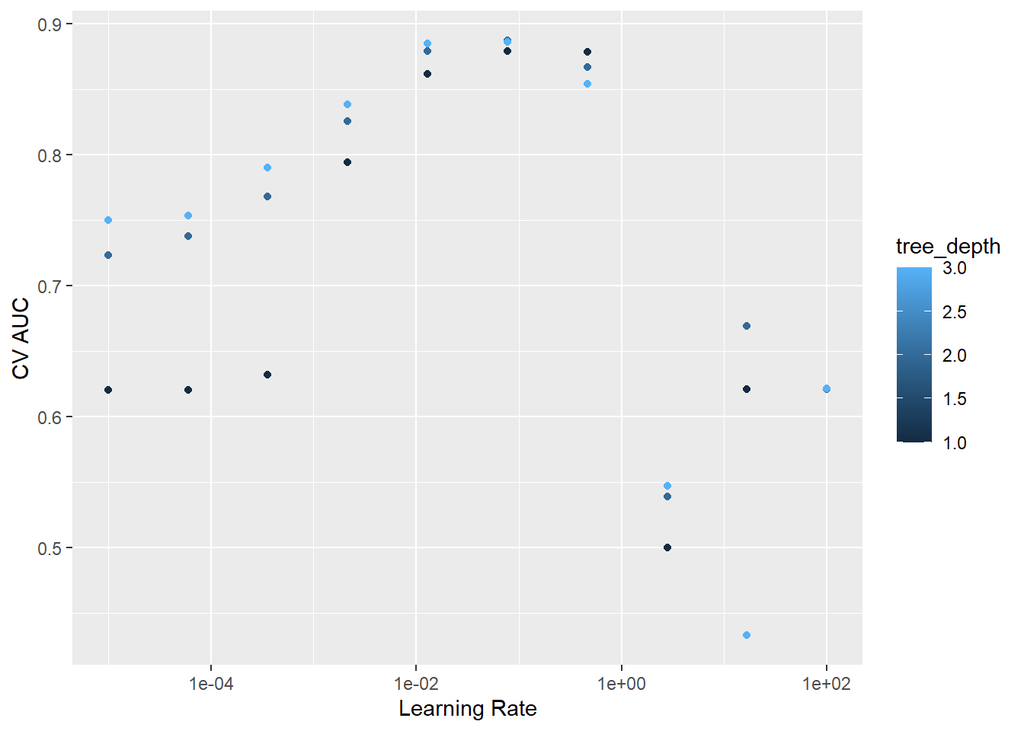

```r
gb_fit %>%
  collect_metrics() %>%
  print(width = Inf) %>%
  filter(.metric == "roc_auc") %>%
  ggplot(mapping = aes(x = learn_rate, y = mean, color = tree_depth)) +
  geom_point() +
  labs(x = "Learning Rate", y = "CV AUC") +
  scale_x_log10()
```

Show the top 5 models.

```r
gb_fit %>%
  show_best("roc_auc")
```

```
# A tibble: 5 × 8
  tree_depth learn_rate .metric .estimator  mean     n std_err .config
       <int>      <dbl> <chr>   <chr>      <dbl> <int>   <dbl> <chr>
1          2     0.0774 roc_auc binary     0.887     5 0.00332 Preprocessor1_Mo…
2          3     0.0774 roc_auc binary     0.886     5 0.00280 Preprocessor1_Mo…
3          3     0.0129 roc_auc binary     0.885     5 0.00292 Preprocessor1_Mo…
4          2     0.0129 roc_auc binary     0.879     5 0.00293 Preprocessor1_Mo…
5          1     0.0774 roc_auc binary     0.879     5 0.00344 Preprocessor1_Mo…
```

Let’s select the best model.

```r
best_gb <- gb_fit %>%
  select_best("roc_auc")
best_gb
```

```
# A tibble: 1 × 3
  tree_depth learn_rate .config
       <int>      <dbl> <chr>
1          2     0.0774 Preprocessor1_Model17
```

## 23 Finalize our model

Now we are done tuning. Finally, let’s fit this final model to the whole training data and use our test data to estimate the model performance we expect to see with new data.

```r
# Final workflow
gb_final_wf <- gb_wf %>%
  finalize_workflow(best_gb)
gb_final_wf
```

```
══ Workflow ════════════════════════════════════════════════════════════════════
Preprocessor: Recipe
Model: boost_tree()

── Preprocessor ────────────────────────────────────────────────────────────────
6 Recipe Steps

• step_impute_median()
• step_impute_mode()
• step_mutate()
• step_dummy()
• step_zv()
• step_normalize()

── Model ───────────────────────────────────────────────────────────────────────
Boosted Tree Model Specification (classification)

Main Arguments:
  trees = 1000
  tree_depth = 2
  learn_rate = 0.0774263682681127

Computational engine: xgboost
```

```r
# Fit the whole training set, then predict the test cases
gb_final_fit <-
  gb_final_wf %>%
  last_fit(data_split)
gb_final_fit
```

```
# Resampling results
# Manual resampling
# A tibble: 1 × 6
  splits                id               .metrics .notes   .predict…¹ .workflow
  <list>                <chr>            <list>   <list>   <list>     <list>
1 <split [26532/26533]> train/test split <tibble> <tibble> <tibble>   <workflow>
# … with abbreviated variable name ¹.predictions
```

```r
# Test metrics
gb_final_fit %>%
  collect_metrics()
```

```
# A tibble: 2 × 4
  .metric  .estimator .estimate .config
  <chr>    <chr>          <dbl> <chr>
1 accuracy binary         0.933 Preprocessor1_Model1
2 roc_auc  binary         0.892 Preprocessor1_Model1
```